# Commissariamenti comunali in Campania: Machine Learning per mappare il rischio

```r
# 🔧 Imposta il seed per riproducibilità
set.seed(123)

# RANDOM FORSET
suppressWarnings({
  rf_fit <- train(
    x = X_train,
    y = y_train,
    method = "rf",
    metric = "ROC",
    trControl = ctrl
  )
})
```

```r
print(rf_fit)
```

```
## Random Forest
##
## 413 samples
##  22 predictor
##   2 classes: 'NO', 'YES'
##
## No pre-processing
## Resampling: Cross-Validated (10 fold, repeated 5 times)
## Summary of sample sizes: 371, 372, 372, 371, 371, 373, ...
## Addtional sampling using ROSE
##
## Resampling results across tuning parameters:
##
##   mtry  ROC        Sens       Spec
##    2    0.9096886  0.8384444  0.8200000
##   12    0.9127439  0.8311905  0.8520000
##   22    0.9100048  0.8251587  0.8333333
##
## ROC was used to select the optimal model using the largest value.
## The final value used for the model was mtry = 12.
```

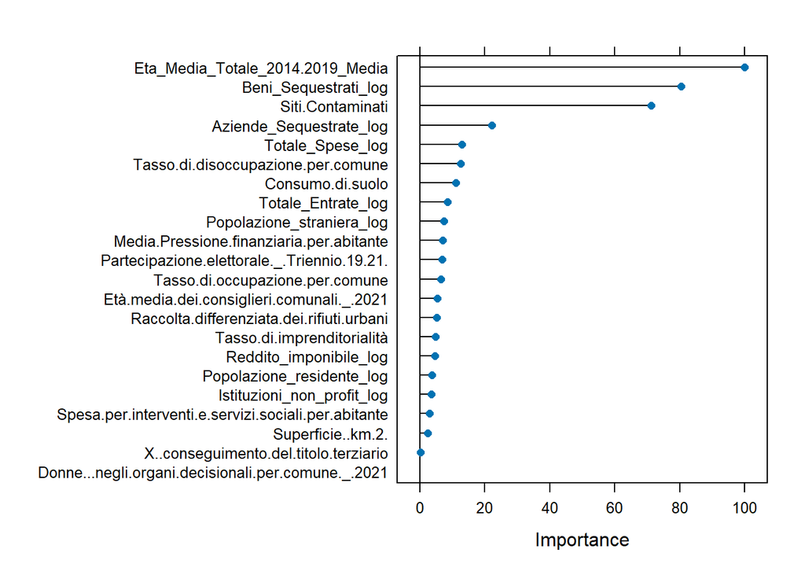

```r
plot(varImp(rf_fit))
```

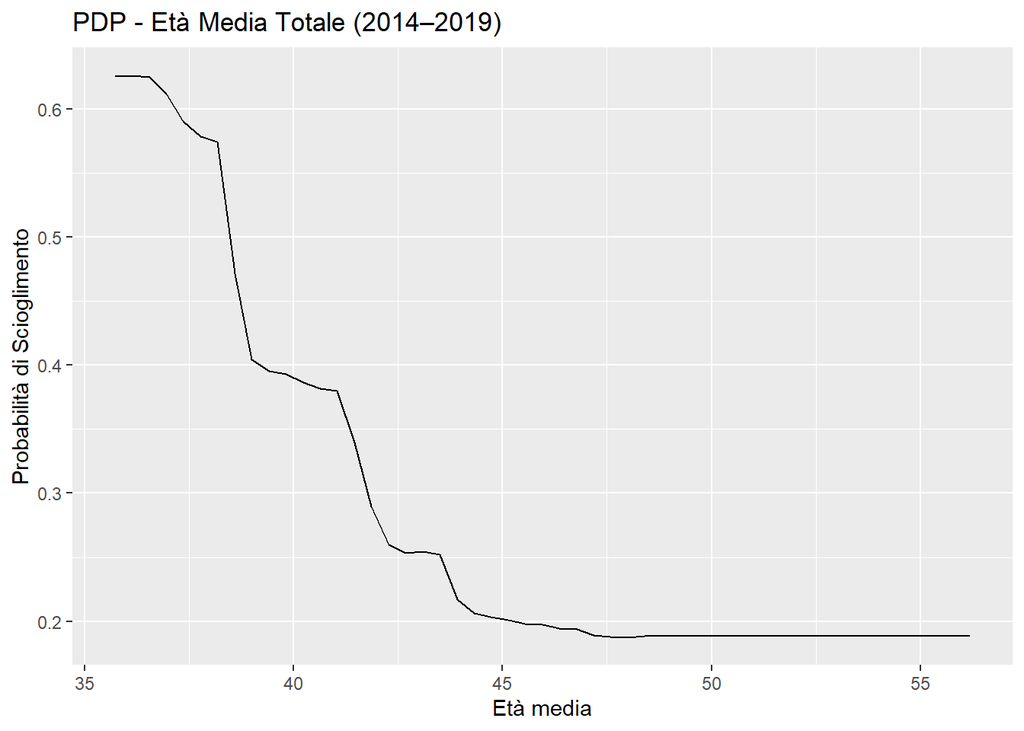

```r
# Assicurati di usare le funzioni corrette del pacchetto pdp
partial <- pdp::partial

# Partial dependence plot - Età media totale (2014–2019)
pdp_eta <- partial(
  object = rf_fit$finalModel,
  pred.var = "Eta_Media_Totale_2014.2019_Media",
  train = X_train,
  prob = TRUE,
  which.class = "YES",
  type = "classification",
  .f = function(object, newdata) {
    predict(object, newdata = newdata, type = "prob")[, "YES"]
  }
)

# Plot
autoplot(pdp_eta) +
  labs(
    title = "PDP - Età Media Totale (2014–2019)",
    x = "Età media",
    y = "Probabilità di Scioglimento"
  )
```

Quando l’età media è bassa (circa 35–40 anni), la probabilità di scioglimento è alta (fino al 65%).

La probabilità scende rapidamente fino a circa 45 anni.

Oltre i 45–50 anni, la curva si appiattisce, indicando che l’età non ha più un grande effetto: la probabilità resta bassa (circa 20% o meno).

```r
library(pdp)
```

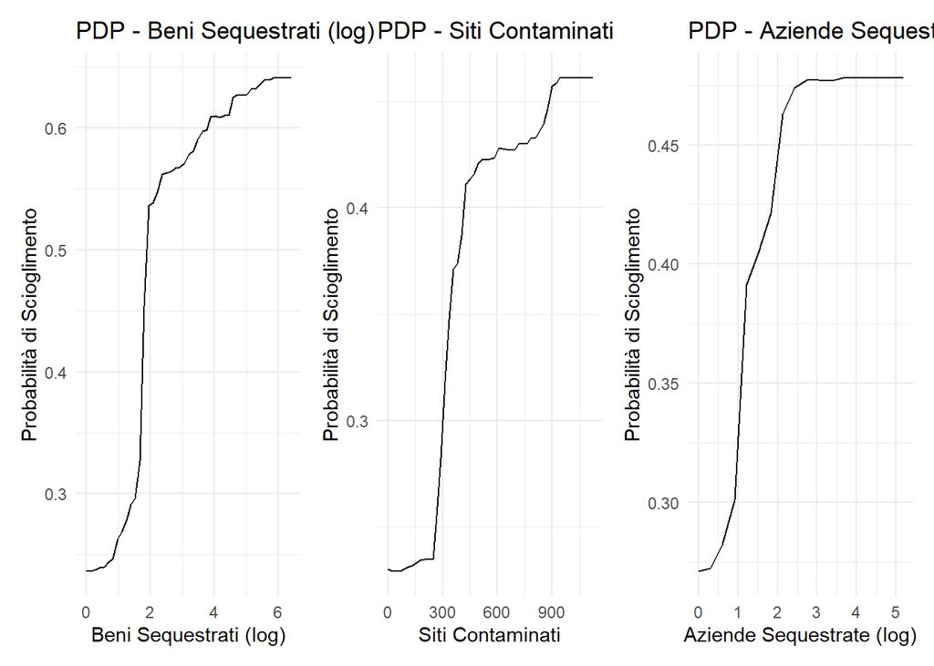

```r
library(ggplot2)
library(patchwork)

# Funzione PDP per una singola variabile
make_pdp_plot <- function(var_name, display_name) {
  pdp <- partial(
    object = rf_fit$finalModel,
    pred.var = var_name,
    train = X_train,
    prob = TRUE,
    which.class = "YES",
    type = "classification",
    .f = function(object, newdata) {
      predict(object, newdata = newdata, type = "prob")[, "YES"]
    }
  )

  autoplot(pdp) +
    labs(
      title = paste("PDP -", display_name),
      x = display_name,
      y = "Probabilità di Scioglimento"
    ) +
    theme_minimal()
}

# Crea i singoli grafici
p1 <- make_pdp_plot("Beni_Sequestrati_log", "Beni Sequestrati (log)")
p2 <- make_pdp_plot("Siti.Contaminati", "Siti Contaminati")
p3 <- make_pdp_plot("Aziende_Sequestrate_log", "Aziende Sequestrate (log)")

# Combina i grafici in una griglia
p1 + p2 + p3
```

L’analisi tramite Partial Dependence Plot (PDP) consente di esaminare in modo più dettagliato la relazione tra alcune variabili esplicative e la probabilità stimata di scioglimento del comune per infiltrazioni mafiose, isolando l’effetto marginale di ciascun predittore. In questo caso, i grafici si concentrano sulle tre variabili risultate tra le più importanti nella Random Forest: beni sequestrati, siti contaminati e aziende sequestrate.

Nel primo grafico, relativo ai beni immobili sequestrati, si osserva una chiara relazione crescente: all’aumentare del numero di beni sequestrati (in scala logaritmica), la probabilità di scioglimento cresce in modo netto, con un’accelerazione visibile già ai primi valori non nulli. Questo risultato suggerisce che anche una quantità contenuta di beni sequestrati è un forte segnale di rischio per la tenuta istituzionale del territorio.

Nel complesso, i grafici confermano che indicatori legati alla criminalità economica e ambientale sono fortemente predittivi del rischio di scioglimento. La capacità del modello di cogliere questi segnali in modo non lineare rafforza la validità dell’approccio machine learning nel trattare fenomeni complessi e latenti come l’infiltrazione mafiosa.

```r
# 🔧 Imposta il seed per riproducibilità
set.seed(12)

#  Lasso (glmnet con alpha = 1)
suppressWarnings({
  lasso_fit <- train(
    x = X_train,
    y = y_train,
    method = "glmnet",
    metric = "ROC",
    trControl = ctrl,
    tuneGrid = expand.grid(
      alpha = 1,  # LASSO
      lambda = seq(0.001, 0.1, length = 100)
    )
  )
})
```

```r
# Miglior valore di lambda
best_lambda <- lasso_fit$bestTune$lambda
print(best_lambda)
```

```
## [1] 0.04
```

```r
# Mostra i risultati completi
print(lasso_fit)
```

```
## glmnet
##
## 413 samples
##  22 predictor
##   2 classes: 'NO', 'YES'
##
## No pre-processing
## Resampling: Cross-Validated (10 fold, repeated 5 times)
## Summary of sample sizes: 372, 372, 372, 371, 373, 371, ...
## Addtional sampling using ROSE
##
## Resampling results across tuning parameters:
##
##   lambda  ROC        Sens       Spec
##   0.001   0.9243476  0.8563016  0.8246667
##   0.002   0.9252825  0.8591111  0.8246667
##   0.003   0.9257556  0.8591111  0.8246667
##   0.004   0.9261259  0.8608095  0.8286667
##   0.005   0.9263857  0.8608095  0.8253333
##   0.006   0.9262931  0.8602540  0.8220000
##   0.007   0.9270016  0.8608095  0.8220000
##   0.008   0.9271466  0.8613810  0.8220000
##   0.009   0.9276582  0.8619365  0.8220000
##   0.010   0.9286106  0.8619206  0.8273333
##   0.011   0.9285365  0.8624762  0.8273333
##   0.012   0.9288857  0.8619206  0.8273333
##   0.013   0.9294159  0.8608254  0.8233333
##   0.014   0.9296196  0.8596984  0.8306667
##   0.015   0.9291910  0.8602540  0.8306667
##   0.016   0.9294905  0.8596984  0.8306667
##   0.017   0.9293820  0.8591429  0.8340000
##   0.018   0.9292677  0.8585873  0.8340000
##   0.019   0.9295265  0.8574762  0.8340000
##   0.020   0.9297640  0.8574762  0.8340000
##   0.021   0.9290820  0.8563651  0.8340000
##   0.022   0.9284683  0.8569206  0.8340000
##   0.023   0.9283016  0.8563651  0.8300000
##   0.024   0.9280021  0.8563651  0.8300000
##   0.025   0.9282825  0.8563492  0.8340000
##   0.026   0.9279836  0.8563492  0.8340000
```

[output cut: 63 more lines]

```
##   0.090   0.9258746  0.8485714  0.8233333
##   0.091   0.9258746  0.8480159  0.8233333
##   0.092   0.9259672  0.8474603  0.8233333
##   0.093   0.9258746  0.8474603  0.8273333
##   0.094   0.9257794  0.8474603  0.8273333
##   0.095   0.9256683  0.8469048  0.8273333
##   0.096   0.9255730  0.8469048  0.8273333
##   0.097   0.9253720  0.8463492  0.8273333
##   0.098   0.9255788  0.8463492  0.8273333
##   0.099   0.9249836  0.8463492  0.8273333
##   0.100   0.9250053  0.8463492  0.8273333
##
## Tuning parameter 'alpha' was held constant at a value of 1
## ROC was used to select the optimal model using the largest value.
## The final values used for the model were alpha = 1 and lambda = 0.04.
```

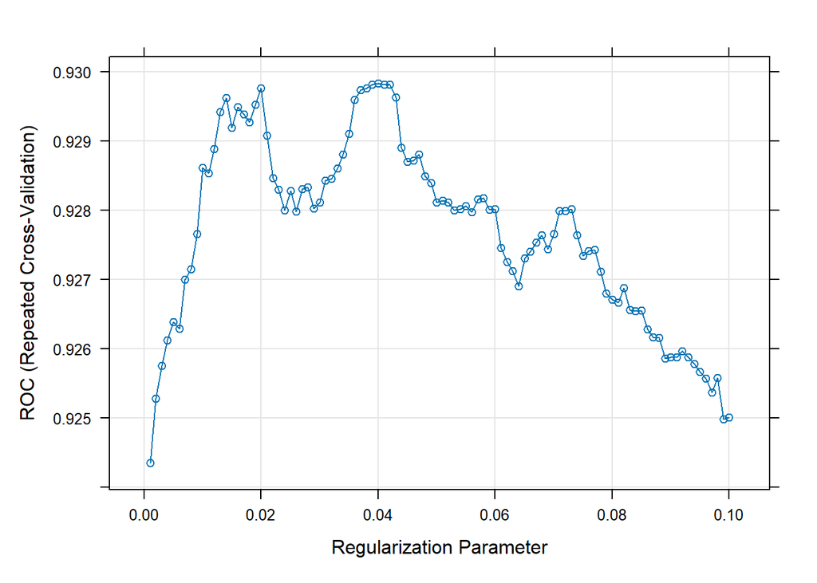

```r
# Visualizza graficamente l’andamento dell’AUC in funzione di lambda
plot(lasso_fit)
```

```r
print(lasso_fit)
```

```
## glmnet
##
## 413 samples
##  22 predictor
##   2 classes: 'NO', 'YES'
##
## No pre-processing
## Resampling: Cross-Validated (10 fold, repeated 5 times)
## Summary of sample sizes: 372, 372, 372, 371, 373, 371, ...
## Addtional sampling using ROSE
##
## Resampling results across tuning parameters:
##
##   lambda  ROC        Sens       Spec
##   0.001   0.9243476  0.8563016  0.8246667
##   0.002   0.9252825  0.8591111  0.8246667
##   0.003   0.9257556  0.8591111  0.8246667
##   0.004   0.9261259  0.8608095  0.8286667
##   0.005   0.9263857  0.8608095  0.8253333
##   0.006   0.9262931  0.8602540  0.8220000
##   0.007   0.9270016  0.8608095  0.8220000
##   0.008   0.9271466  0.8613810  0.8220000
##   0.009   0.9276582  0.8619365  0.8220000
##   0.010   0.9286106  0.8619206  0.8273333
##   0.011   0.9285365  0.8624762  0.8273333
##   0.012   0.9288857  0.8619206  0.8273333
##   0.013   0.9294159  0.8608254  0.8233333
##   0.014   0.9296196  0.8596984  0.8306667
##   0.015   0.9291910  0.8602540  0.8306667
##   0.016   0.9294905  0.8596984  0.8306667
##   0.017   0.9293820  0.8591429  0.8340000
##   0.018   0.9292677  0.8585873  0.8340000
##   0.019   0.9295265  0.8574762  0.8340000
##   0.020   0.9297640  0.8574762  0.8340000
##   0.021   0.9290820  0.8563651  0.8340000
##   0.022   0.9284683  0.8569206  0.8340000
##   0.023   0.9283016  0.8563651  0.8300000
##   0.024   0.9280021  0.8563651  0.8300000
##   0.025   0.9282825  0.8563492  0.8340000
##   0.026   0.9279836  0.8563492  0.8340000
```

[output cut: 63 more lines]

```
##   0.090   0.9258746  0.8485714  0.8233333
##   0.091   0.9258746  0.8480159  0.8233333
##   0.092   0.9259672  0.8474603  0.8233333
##   0.093   0.9258746  0.8474603  0.8273333
##   0.094   0.9257794  0.8474603  0.8273333
##   0.095   0.9256683  0.8469048  0.8273333
##   0.096   0.9255730  0.8469048  0.8273333
##   0.097   0.9253720  0.8463492  0.8273333
##   0.098   0.9255788  0.8463492  0.8273333
##   0.099   0.9249836  0.8463492  0.8273333
##   0.100   0.9250053  0.8463492  0.8273333
##
## Tuning parameter 'alpha' was held constant at a value of 1
## ROC was used to select the optimal model using the largest value.
## The final values used for the model were alpha = 1 and lambda = 0.04.
```

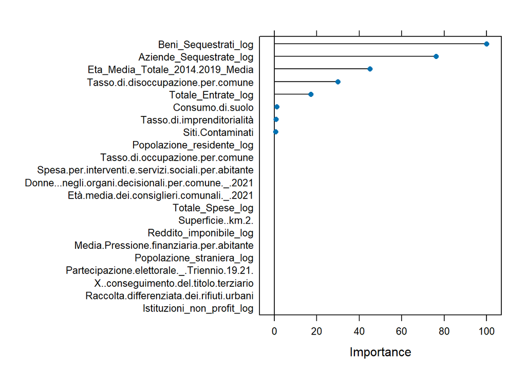

```r
plot(varImp(lasso_fit))
```

```r
library(ICEbox)
X_train_num <- X_train[, sapply(X_train, is.numeric)]
X_train_num <- as.data.frame(X_train_num)
X_train_num$Beni_Sequestrati_log <- as.numeric(X_train_num$Beni_Sequestrati_log)


lasso_model <- lasso_fit$finalModel

lasso_predict_fun <- function(object, newdata) {
  newdata_mat <- model.matrix(~ ., data = newdata)[, -1]
  predict(object,
          newx = newdata_mat,
          type = "response",
          s = lasso_fit$bestTune$lambda)[, 1]
}

#ICE object
ice_lasso <- ice(
  object = lasso_model,
  X = X_train_num,
  predictor = "Beni_Sequestrati_log",
  predictfcn = lasso_predict_fun
)
```

```
## ...............................................
## y not passed, so range_y is range of ice curves and sd_y is sd of predictions on real observations
```

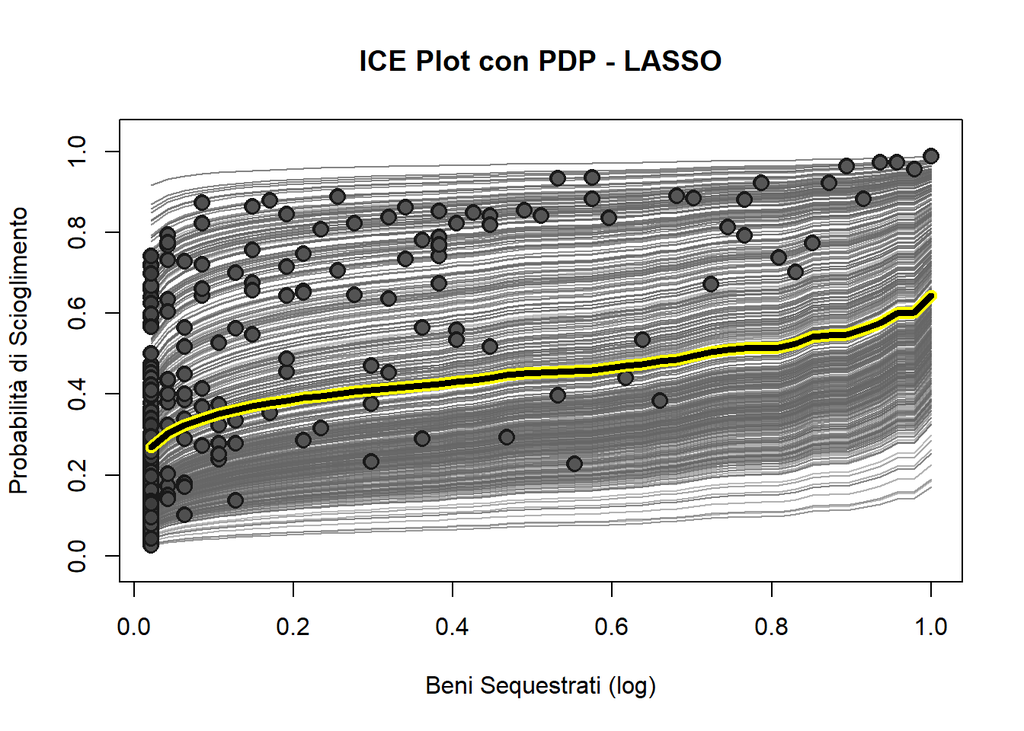

```r
# Plot con curva media (PDP)
plot(ice_lasso,
     plot_pdp = TRUE,
     ylab = "Probabilità di Scioglimento",
     xlab = "Beni Sequestrati (log)",
     main = "ICE Plot con PDP - LASSO")
```

L’analisi condotta tramite ICE Plot, arricchita dalla curva media PDP, evidenzia come nel modello LASSO la variabile Beni_Sequestrati_log presenti una relazione positiva con la probabilità stimata di scioglimento del comune per infiltrazioni mafiose.

In particolare, la curva media gialla mostra che all’aumentare (anche minimo) dei beni immobili sequestrati, la probabilità predetta dal modello cresce in modo progressivo, confermando che questa variabile rappresenta un segnale informativo rilevante.

Le linee individuali grigie (ICE) mostrano un certo grado di eterogeneità tra i comuni, ma l’inclinazione generale è coerente con il pattern medio, rafforzando la robustezza dell’effetto appreso.

Questo risultato è in linea con l’aspettativa teorica secondo cui la presenza di beni sequestrati può indicare un radicamento della criminalità organizzata sul territorio e quindi una maggiore vulnerabilità delle istituzioni locali.

```r
# 🔧 Imposta il seed per riproducibilità
set.seed(123)

# 🔸 Gradient Boosting Machine (GBM)
suppressWarnings({
  gbm_fit <- train(
    x = X_train,
    y = y_train,
    method = "gbm",
    verbose = FALSE,
    metric = "ROC",
    trControl = ctrl,
    tuneGrid = expand.grid(
      n.trees = c(50, 100, 150),
      interaction.depth = c(1, 3, 5),
      shrinkage = c(0.01, 0.1),
      n.minobsinnode = 10
    )
  )
})
```

```r
print(gbm_fit)
```

```
## Stochastic Gradient Boosting
##
## 413 samples
##  22 predictor
##   2 classes: 'NO', 'YES'
##
## No pre-processing
## Resampling: Cross-Validated (10 fold, repeated 5 times)
## Summary of sample sizes: 371, 372, 372, 371, 371, 373, ...
## Addtional sampling using ROSE
##
## Resampling results across tuning parameters:
##
##   shrinkage  interaction.depth  n.trees  ROC        Sens       Spec
##   0.01       1                   50      0.9096254  0.8194762  0.8353333
##   0.01       1                  100      0.9139101  0.8267460  0.8560000
##   0.01       1                  150      0.9149907  0.8317619  0.8453333
##   0.01       3                   50      0.9078315  0.8266508  0.8280000
##   0.01       3                  100      0.9109492  0.8284127  0.8393333
##   0.01       3                  150      0.9118048  0.8323333  0.8393333
##   0.01       5                   50      0.9070151  0.8204603  0.8366667
##   0.01       5                  100      0.9072280  0.8299841  0.8366667
##   0.01       5                  150      0.9072476  0.8378254  0.8286667
##   0.10       1                   50      0.9168508  0.8406190  0.8013333
##   0.10       1                  100      0.9172423  0.8490476  0.7973333
##   0.10       1                  150      0.9163291  0.8512698  0.7966667
##   0.10       3                   50      0.9086048  0.8372698  0.8273333
##   0.10       3                  100      0.9051608  0.8434444  0.8120000
##   0.10       3                  150      0.9053852  0.8422857  0.8080000
##   0.10       5                   50      0.9152656  0.8418095  0.8426667
##   0.10       5                  100      0.9110968  0.8423651  0.8240000
##   0.10       5                  150      0.9095344  0.8418571  0.8273333
##
## Tuning parameter 'n.minobsinnode' was held constant at a value of 10
## ROC was used to select the optimal model using the largest value.
## The final values used for the model were n.trees = 100, interaction.depth =
##  1, shrinkage = 0.1 and n.minobsinnode = 10.
```

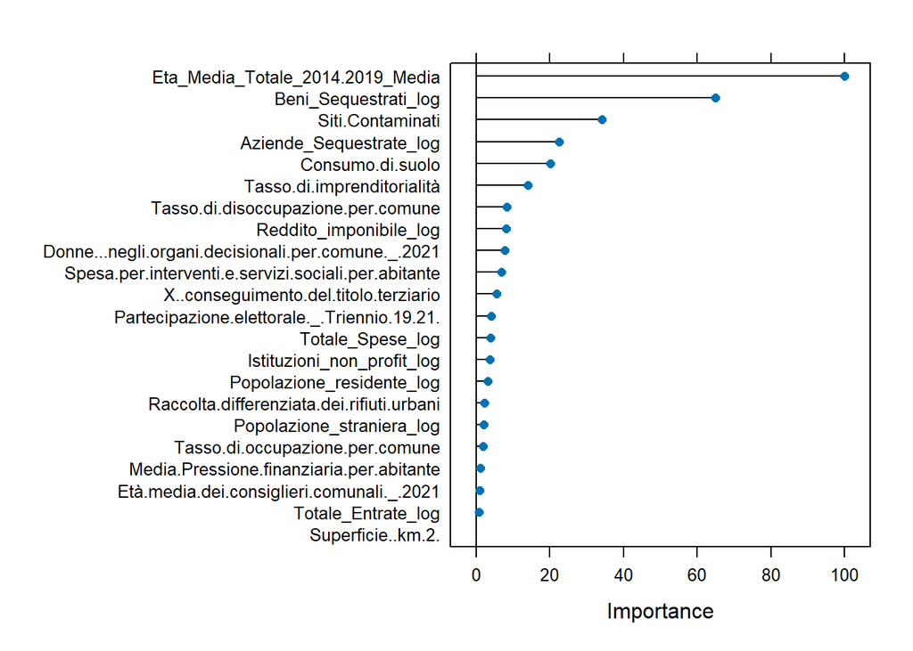

```r
plot(varImp(gbm_fit))
```

```r
# 🔧 Imposta il seed per riproducibilità
set.seed(123)

# 🔸 Neural Network (nnet)
suppressWarnings({
  nnet_fit <- train(
    x = X_train,
    y = y_train,
    method = "nnet",
    metric = "ROC",
    trControl = ctrl,
    trace = FALSE,
    tuneGrid = expand.grid(
      size = c(3, 5, 7),       # numero di neuroni nel layer nascosto
      decay = c(0.01, 0.1, 0.5)  # regolarizzazione
    )
  )
})
```

```r
print(nnet_fit)
```

```
## Neural Network
##
## 413 samples
##  22 predictor
##   2 classes: 'NO', 'YES'
##
## No pre-processing
## Resampling: Cross-Validated (10 fold, repeated 5 times)
## Summary of sample sizes: 371, 372, 372, 371, 371, 373, ...
## Addtional sampling using ROSE
##
## Resampling results across tuning parameters:
##
##   size  decay  ROC        Sens       Spec
##   3     0.01   0.8581754  0.8243333  0.8313333
##   3     0.10   0.8778513  0.8188889  0.8200000
##   3     0.50   0.8944164  0.8228413  0.8320000
##   5     0.01   0.8660336  0.8088095  0.8220000
##   5     0.10   0.8762817  0.8205873  0.8146667
##   5     0.50   0.8928429  0.8194286  0.8233333
##   7     0.01   0.8527455  0.8177937  0.8240000
##   7     0.10   0.8631376  0.8200794  0.7900000
##   7     0.50   0.8744029  0.8116349  0.8166667
##
## ROC was used to select the optimal model using the largest value.
## The final values used for the model were size = 3 and decay = 0.5.
```

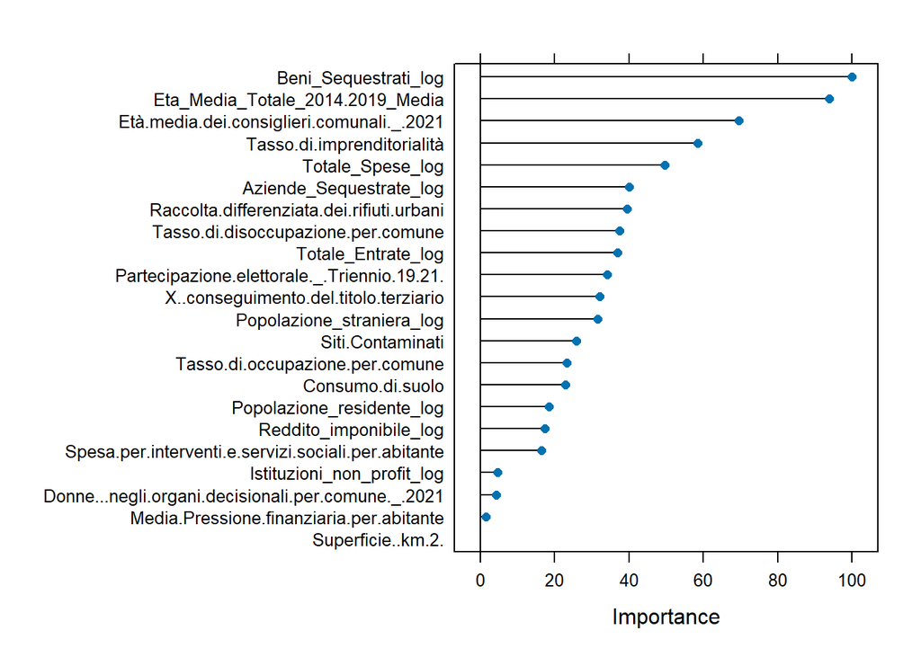

```r
plot(varImp(nnet_fit))
```

```r
# 🔧 Imposta il seed per riproducibilità
set.seed(123)

# 🔸 Logistic Regression
suppressWarnings({
  logit_fit <- train(
    x = X_train,
    y = y_train,
    method = "glm",
    metric = "ROC",
    trControl = ctrl
  )
})
```

```r
print(logit_fit)
```

```
## Generalized Linear Model
##
## 413 samples
##  22 predictor
##   2 classes: 'NO', 'YES'
##
## No pre-processing
## Resampling: Cross-Validated (10 fold, repeated 5 times)
## Summary of sample sizes: 371, 372, 372, 371, 371, 373, ...
## Addtional sampling using ROSE
##
## Resampling results:
##
##   ROC        Sens       Spec
##   0.9212894  0.8568254  0.8106667
```

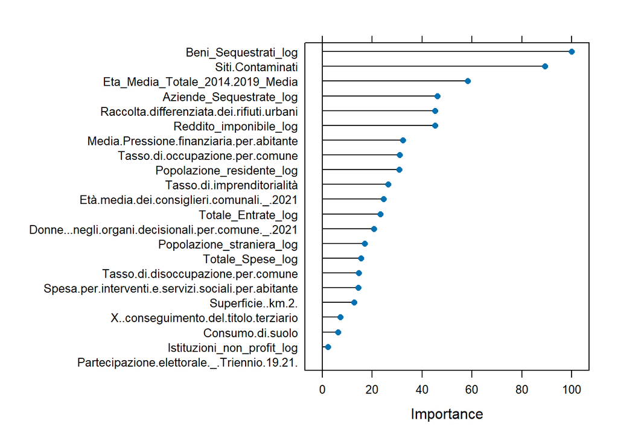

```r
plot(varImp(logit_fit))
```

```r
# 📦 Metti tutti i modelli in una lista per confronto
model_list <- list(
  RF = rf_fit,
  LASSO = lasso_fit,
  GBM = gbm_fit,
  NN = nnet_fit,
  Logit = logit_fit
)

# 📌 Assicurati che il target nel test set sia un fattore con livelli validi
test_labels <- factor(y_test, levels = c("NO", "YES"))

# 📈 Calcolo AUC per ogni modello
library(pROC)

roc_values <- lapply(model_list, function(model) {
  probs <- predict(model, newdata = X_test, type = "prob")[, "YES"]
  roc_obj <- roc(response = test_labels, predictor = probs)
  auc(roc_obj)
})
# 📊 Mostra i valori AUC
print(roc_values)
```

```
## $RF
## Area under the curve: 0.8908
##
## $LASSO
## Area under the curve: 0.929
##
## $GBM
## Area under the curve: 0.9104
##
## $NN
## Area under the curve: 0.8504
##
## $Logit
## Area under the curve: 0.9062
```

```r
sort(unlist(roc_values), decreasing = TRUE)
```

```
##     LASSO       GBM     Logit        RF        NN
## 0.9290383 0.9103641 0.9061625 0.8907563 0.8503735
```

```r
# Calcola le curve ROC e salvale in una lista
roc_list <- lapply(model_list, function(model) {
  probs <- predict(model, newdata = X_test, type = "prob")[, "YES"]
  roc(response = y_test, predictor = probs, levels = c("NO", "YES"), direction = "<")
})

# Stampa gli AUC
sapply(roc_list, auc)
```

```
##        RF     LASSO       GBM        NN     Logit
## 0.8907563 0.9290383 0.9103641 0.8503735 0.9061625
```

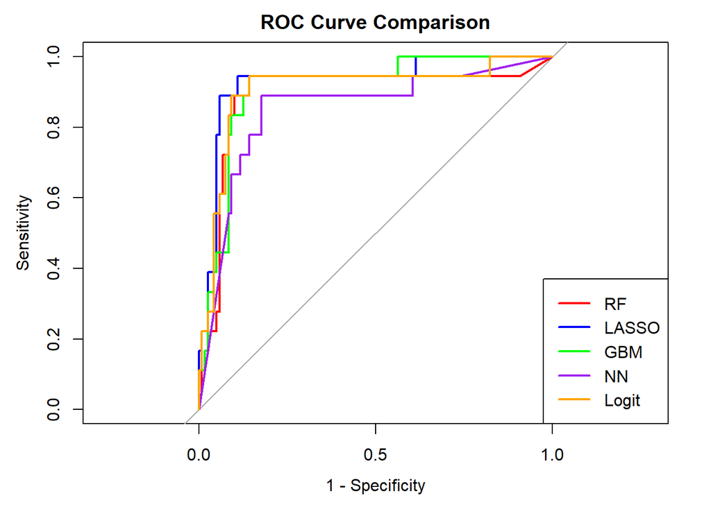

```r
# Colori per le curve
colors <- c("RF" = "red", "LASSO" = "blue", "GBM" = "green", "NN" = "purple", "Logit" = "orange")

# Plot base
plot(roc_list[[1]], col = colors[1], main = "ROC Curve Comparison", legacy.axes = TRUE)
for(i in 2:length(roc_list)) {
  plot(roc_list[[i]], col = colors[i], add = TRUE)
}
legend("bottomright", legend = names(roc_list), col = colors, lwd = 2)
```

Il grafico mostra il confronto tra i modelli predittivi in termini di curva ROC (Receiver Operating Characteristic), utile per valutare la capacità del classificatore di distinguere tra comuni che verranno sciolti per infiltrazioni mafiose (classe “YES”) e quelli che non lo saranno (“NO”).

Tutti i modelli mostrano buone prestazioni, con curve molto vicine all’angolo in alto a sinistra del grafico — indicativo di alta sensibilità e specificità. In particolare:

Neural Network (viola) appare leggermente inferiore, con una curva leggermente più distante dalla diagonale perfetta, a conferma anche dei risultati meno brillanti emersi dalla confusion matrix.

```r
roc_rf <- roc_list[["RF"]]
roc_lasso <- roc_list[["LASSO"]]
roc_gbm <- roc_list[["GBM"]]
roc_nn <- roc_list[["NN"]]
roc_logit <- roc_list[["Logit"]]

# Test di DeLong (RF vs altri)
roc.test(roc_rf, roc_lasso)  # RF vs LASSO
```

```
##
##  DeLong's test for two correlated ROC curves
##
## data:  roc_rf and roc_lasso
## Z = -1.9231, p-value = 0.05447
## alternative hypothesis: true difference in AUC is not equal to 0
## 95 percent confidence interval:
##  -0.0772983591  0.0007344002
## sample estimates:
## AUC of roc1 AUC of roc2
##   0.8907563   0.9290383
```

```r
roc.test(roc_rf, roc_gbm)    # RF vs GBM
```

```
##
##  DeLong's test for two correlated ROC curves
##
## data:  roc_rf and roc_gbm
## Z = -0.8041, p-value = 0.4213
## alternative hypothesis: true difference in AUC is not equal to 0
## 95 percent confidence interval:
##  -0.06740140  0.02818571
## sample estimates:
## AUC of roc1 AUC of roc2
##   0.8907563   0.9103641
```

```r
roc.test(roc_rf, roc_nn)     # RF vs NN
```

```
##
##  DeLong's test for two correlated ROC curves
##
## data:  roc_rf and roc_nn
## Z = 1.2365, p-value = 0.2163
## alternative hypothesis: true difference in AUC is not equal to 0
## 95 percent confidence interval:
##  -0.02362654  0.10439218
## sample estimates:
## AUC of roc1 AUC of roc2
##   0.8907563   0.8503735
```

```r
roc.test(roc_rf, roc_logit)  # RF vs Logit
```

```
##
##  DeLong's test for two correlated ROC curves
##
## data:  roc_rf and roc_logit
## Z = -1.4351, p-value = 0.1513
## alternative hypothesis: true difference in AUC is not equal to 0
## 95 percent confidence interval:
##  -0.036447407  0.005635082
## sample estimates:
## AUC of roc1 AUC of roc2
##   0.8907563   0.9061625
```

```r
for (name in names(model_list)) {
  cat("\n---", name, "---\n")
  pred <- predict(model_list[[name]], newdata = X_test)
  print(confusionMatrix(pred, y_test, positive = "YES"))
}
```

```
##
## --- RF ---
## Confusion Matrix and Statistics
##
##           Reference
## Prediction NO YES
##        NO  99   1
##        YES 20  17
##
##                Accuracy : 0.8467
##                  95% CI : (0.7753, 0.9025)
##     No Information Rate : 0.8686
##     P-Value [Acc > NIR] : 0.814
##
##                   Kappa : 0.5362
##
##  Mcnemar's Test P-Value : 8.568e-05
##
##             Sensitivity : 0.9444
##             Specificity : 0.8319
##          Pos Pred Value : 0.4595
##          Neg Pred Value : 0.9900
##              Prevalence : 0.1314
##          Detection Rate : 0.1241
##    Detection Prevalence : 0.2701
##       Balanced Accuracy : 0.8882
##
##        'Positive' Class : YES
##
##
## --- LASSO ---
## Confusion Matrix and Statistics
##
##           Reference
## Prediction  NO YES
##        NO  105   1
##        YES  14  17
##
##                Accuracy : 0.8905
##                  95% CI : (0.8258, 0.9374)
```

[output cut: 90 more lines]

```
##                   Kappa : 0.5672
##
##  Mcnemar's Test P-Value : 0.002183
##
##             Sensitivity : 0.8889
##             Specificity : 0.8655
##          Pos Pred Value : 0.5000
##          Neg Pred Value : 0.9810
##              Prevalence : 0.1314
##          Detection Rate : 0.1168
##    Detection Prevalence : 0.2336
##       Balanced Accuracy : 0.8772
##
##        'Positive' Class : YES
##
```

L’analisi condotta mostra come l’impiego di modelli predittivi basati su dati territoriali e istituzionali possa offrire un contributo concreto alla prevenzione delle infiltrazioni mafiose nella pubblica amministrazione. La possibilità di identificare in anticipo i comuni a più alto rischio di scioglimento permette ai decisori pubblici di superare un approccio meramente reattivo e orientarsi verso forme di intervento proattivo e mirato.

Queste evidenze hanno ricadute rilevanti su più livelli:

Prevenzione mirata: strumenti predittivi possono supportare l’attività di prefetture, commissari straordinari e autorità anticorruzione nell’individuare territori vulnerabili, anche in assenza di segnali espliciti.

Supporto istituzionale selettivo: i risultati possono guidare l’allocazione di risorse per rafforzare la capacità amministrativa e il presidio della legalità nei contesti più esposti, attraverso formazione, auditing o accompagnamento tecnico.

Sorveglianza strategica: una dashboard predittiva, aggiornata periodicamente, consentirebbe un monitoraggio dinamico delle condizioni di rischio a livello comunale, aiutando a costruire una risposta istituzionale più tempestiva e meno politicizzata.

In sintesi, il lavoro mostra che la combinazione tra approccio statistico e conoscenza territoriale può rappresentare una nuova frontiera nella lotta contro le infiltrazioni criminali, contribuendo a tutelare il corretto funzionamento delle istituzioni locali e la fiducia dei cittadini.